# Problem Set 9

Due date: 4 December

Please upload your completed assignment to the ELMs course site (under the assignments menu). Remember to include an annotated script file for all work with R and show your math for all other problems (if applicable, or necessary). Please also upload your completed assignment to the Github repository that you have shared with us. *We should be able to run your script with no errors.*

**Total points: 40**

```r
library(tidyverse)
library(broom)
library(modelsummary)
library(ggdist)
library(marginaleffects)
library(poliscidata)
```

## Question 1

*Points: 10*

**Note**

10/10

Table 1 below reports the results from two regression models. In Model 1 in Table 1 $Y$ is regressed on $X_1$ and, in Model 2, $Y$ is regressed on both $X_1$ and $X_2$. Why might $X_1$ be statistically significant at conventional levels in Model 1 but statistically insignificant in Model 2? Be as specific as possible.

[figure not shown]

**Answer**: Firstly, this shift in significance suggests that the relationship between $X_1$ and $Y$ is primarily driven by $X_2$. The coefficient for $X_1$ decreases with the introduction of $X_2$ in the second model, indicating that the effects of $X_1$ on $Y$ are smaller when holding all values of $X_2$ constant. Simply put, $X_2$’s significance and larger coefficient gives it more explanatory value. Finally, these changes in $X_1$’s coefficient and significance level may also point to a potential correlation between $X_1$ and $X_2$.

## Question 2

*Points: 10*

**Note**

5/10, missing: interpret the regression results.

Using the `censusAggregate` dataset (posted on ELMs), which is survey data aggregated to the state level (1972-2000), estimate a regression with `vote` as the dependent variable and the following independent variables: `nonSouth`, `edr`, and `pcthsg`. Report the results in a professionally formatted table and interpret the regression results.

Also, create a figure to display the predicted values (with confidence intervals) for the effect of `pcthsg` on the turnout rate. Lastly, is it meaningful to interpret the constant term on its own? Why, or why not?

**Note**

`vote` is the turnout rate in a state in a given year (i.e., the number of people who voted divided by the number eligible to vote).

`nonSouth` is a dummy variable equal to `0` for Southern states and a `1` for non-Southern states.

`pcthsg` is the percentage of the population in a state that graduated high school.

`edr` is a dummy variable equal to `1` for states that used election-day registration and a `0` for states without election-day registration.

**Answer**:

```r
#import data
CA_raw <- read_csv(
  here::here("Week 11", "censusAggregate-1.csv"))

#design multivariate regression model
CA_multi <- lm(vote ~ nonSouth + edr + pcthsg, data = CA_raw)

#summarize results
summary(CA_multi)
```

```
Call:
lm(formula = vote ~ nonSouth + edr + pcthsg, data = CA_raw)

Residuals:
     Min       1Q   Median       3Q      Max
-19.6259  -3.3554   0.0282   3.6670  15.9988

Coefficients:
            Estimate Std. Error t value Pr(>|t|)
(Intercept) 54.00180    2.61603  20.643  < 2e-16 ***
nonSouth     5.54555    0.79695   6.958 1.68e-11 ***
edr          5.79234    1.05645   5.483 7.99e-08 ***
pcthsg       0.10074    0.03615   2.787  0.00561 **
---
Signif. codes:  0 '***' 0.001 '**' 0.01 '*' 0.05 '.' 0.1 ' ' 1

Residual standard error: 5.652 on 353 degrees of freedom
Multiple R-squared:  0.2813,    Adjusted R-squared:  0.2752
F-statistic: 46.05 on 3 and 353 DF,  p-value: < 2.2e-16
```

```r
#format summary table
modelsummary(CA_multi,
             coef_rename = c(vote = "State turnout rate",
                             nonSouth = "Southern state",
                             pcthsg = "Graduated high school (Pop. %)",
                             edr = "Election-day registration"),
             statistic = c("t = {statistic}", "SE = {std.error}", "conf.int"))
```

|  | (1) |
| --- | --- |
| (Intercept) | 54.002 |
|  | t = 20.643 |
|  | SE = 2.616 |
|  | [48.857, 59.147] |
| Southern state | 5.546 |
|  | t = 6.958 |
|  | SE = 0.797 |
|  | [3.978, 7.113] |
| Election-day registration | 5.792 |
|  | t = 5.483 |
|  | SE = 1.056 |
|  | [3.715, 7.870] |
| Graduated high school (Pop. %) | 0.101 |
|  | t = 2.787 |
|  | SE = 0.036 |
|  | [0.030, 0.172] |
| Num.Obs. | 357 |
| R2 | 0.281 |
| R2 Adj. | 0.275 |
| AIC | 2255.8 |
| BIC | 2275.2 |
| Log.Lik. | -1122.884 |
| RMSE | 5.62 |

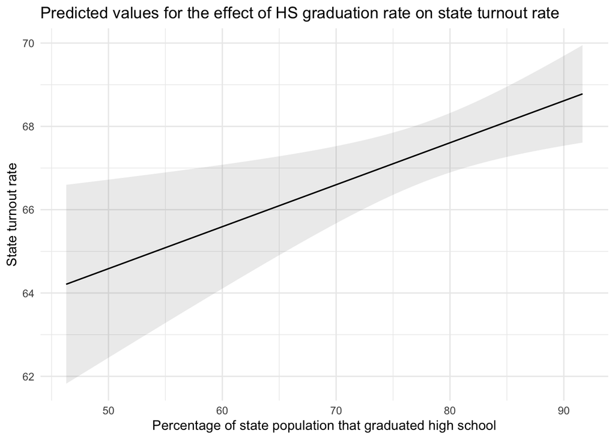

```r
#plot effect pcthsg on vote with CI
plot_predictions(CA_multi, condition = "pcthsg") +
  theme_minimal() +
  labs(x = "Percentage of state population that graduated high school",
       y = "State turnout rate",
       title = "Predicted values for the effect of HS graduation rate on state turnout rate")
```

## Question 3

*Points: 5*

**Note**

2/5

Using the regression results from the previous question, evaluate the null hypothesis that the effects (i.e., regression coefficients) of `nonSouth` and `pcthsg` are jointly equal to zero. Can you reject the null hypothesis? Be sure to demonstrate how you reached a definitive conclusion.

**Note**

You need to formally test whether the full model is statistically different from a model without `nonSouth` and `pcthsg`. We will discuss this in the lab.

**Answer**: *Yes, we can* *reject* *the null hypothesis*. Interpreting the coefficients individually allows us to come to this conclusion.

For `nonSouth`, the data suggests that being a non-Southern state is associated with an increase in state turnout rate of 5.55 percentage points, on average and holding all else constant. The relationship between `nonSouth` and `vote` is highly significant given its extremely low p-value (p =1.68^{-11}). Therefore, we can reject the null.

## Question 4

*Points: 15*

**Note**

15/15

Using one of the other data sets available in the `poliscidata` package pick one dependent variable and two or more independent variables. Run a regression of the dependent variable on the independent variables. In your answer, describe why you picked the variables you did, produce a professionally formatted results table, and describe your statistical and substantive findings.

**Answer**: For my research question, I ask whether authoritative familial leadership translates into authoritarian politics. This question is an extension of work previously done by Cohen and Smith (2016) based on Latin America. I hypothesize that people who favor obedience and punitiveness will score higher on the authoritarian scale.

I use social conservatism (`social_cons3`) and party identification (`party_id3`) as my control variables. I choose these two because they are encompassing and holistic political ideologies rather than familial and private practices of power. In this way, we can evaluate how personal behaviors may translate into political beliefs in isolation.

Finally, my dependent variable will be score on the authoritarianism scale (`authoritarianism`). ::: callout-note As a side note, I could not find how “authoritarianism” variable was operationalized. None of the GSS codebooks I found mentioned an authoritarianism variable despite it being available here. I assumed the values “0”, “8”, and “9” were assigned to “N/A”, “Refused”, and “Don’t know” respectively because most of the other scale variables were organized in the same way. I also assume that the higher value on this scale, the *more* authoritarian. I could be wrong but my analysis will proceed under this assumption. :::

```r
# Organize dataset
gss_df <- poliscidata::gss |>
  select(authoritarianism, obey2, spanking, social_cons3, partyid_3) |>
  filter(!spanking %in% c("Refused", "Don't know"),
         !obey2 %in% c("Refused", "Don't know"),
         !partyid_3 %in% c("Refused", "Don't know"),
         !authoritarianism %in% c("0", "8", "9"),
         !is.na(authoritarianism),
         !is.na(obey2),
         !is.na(spanking),
         !is.na(social_cons3),
         !is.na(partyid_3)) |>
  mutate(
    obey2 = recode(obey2, "Less important" = 0, "More important" = 1),
    spanking = recode(spanking, "STRONGLY DISAGREE" = 0, "DISAGREE" = 1, "AGREE" = 2, "STRONGLY AGREE" = 3),
    social_cons3 = recode(social_cons3, "Liberal" = 0, "Mod" = 1, "Conserv" = 2)
  )


# Convert variables to unordered factors
gss_df$partyid_3 <- factor(gss_df$partyid_3, ordered = FALSE)

# Relevel obey2 to set "Less important" as the reference category
gss_df$partyid_3 <- relevel(gss_df$partyid_3, ref = "Ind")

#quickly review data
tibble(gss_df)
```

```
# A tibble: 574 × 5
   authoritarianism obey2 spanking social_cons3 partyid_3
              <dbl> <dbl>    <dbl>        <dbl> <fct>
 1                4     1        2            0 Rep
 2                1     0        3            0 Dem
 3                2     0        2            0 Ind
 4                1     0        2            0 Dem
 5                3     0        1            0 Ind
 6                3     0        1            0 Ind
 7                2     0        2            0 Ind
 8                5     0        0            2 Ind
 9                6     1        2            2 Rep
10                1     0        3            0 Dem
# ℹ 564 more rows
```

```r
multi_model <- lm(authoritarianism ~ obey2 + spanking + social_cons3 + partyid_3, data = gss_df)

#quick summry
summary(multi_model)
```

```
Call:
lm(formula = authoritarianism ~ obey2 + spanking + social_cons3 +
    partyid_3, data = gss_df)

Residuals:
    Min      1Q  Median      3Q     Max
-2.0450 -1.0310 -0.0424  0.8865  3.1764

Coefficients:
             Estimate Std. Error t value Pr(>|t|)
(Intercept)   1.95840    0.13623  14.376   <2e-16 ***
obey2         2.57994    0.10460  24.666   <2e-16 ***
spanking      0.07255    0.05680   1.277   0.2020
social_cons3  0.14451    0.06903   2.094   0.0367 *
partyid_3Dem -0.13481    0.10789  -1.250   0.2120
partyid_3Rep -0.06109    0.12564  -0.486   0.6270
---
Signif. codes:  0 '***' 0.001 '**' 0.01 '*' 0.05 '.' 0.1 ' ' 1

Residual standard error: 1.126 on 568 degrees of freedom
Multiple R-squared:  0.5425,    Adjusted R-squared:  0.5385
F-statistic: 134.7 on 5 and 568 DF,  p-value: < 2.2e-16
```

```r
#professionally format table
modelsummary(multi_model, stars = FALSE,
             coef_rename = c("obey2" = "Obedience is more important",
                             "spanking" = "Approval of spanking",
                             "social_cons3" = "Conservatism",
                             "partyid_3Rep" = "Republican",
                             "partyid_3Dem" = "Democrat"
             ),
                             statistic = c("t = {statistic}", "SE = {std.error}", "conf.int"))
```

|  | (1) |
| --- | --- |
| (Intercept) | 1.958 |
|  | t = 14.376 |
|  | SE = 0.136 |
|  | [1.691, 2.226] |
| Obedience is more important | 2.580 |
|  | t = 24.666 |
|  | SE = 0.105 |
|  | [2.374, 2.785] |
| Approval of spanking | 0.073 |
|  | t = 1.277 |
|  | SE = 0.057 |
|  | [-0.039, 0.184] |
| Conservatism | 0.145 |
|  | t = 2.094 |
|  | SE = 0.069 |
|  | [0.009, 0.280] |
| Democrat | -0.135 |
|  | t = -1.250 |
|  | SE = 0.108 |
|  | [-0.347, 0.077] |
| Republican | -0.061 |
|  | t = -0.486 |
|  | SE = 0.126 |
|  | [-0.308, 0.186] |
| Num.Obs. | 574 |
| R2 | 0.542 |
| R2 Adj. | 0.538 |
| AIC | 1773.0 |
| BIC | 1803.5 |
| Log.Lik. | -879.507 |
| RMSE | 1.12 |

Surely the most intriguing finding of this regression would be the *extremely significant* relationship between `obey2` and `authoritarianism`. The data suggests that respondents who found obedience to be more important in a child’s upbrining were associated with higher scores on the authoritarianism scale. Holding all else equal, respondents who answered “more important” scored 2.58 points higher on average compared to respondents who answered “less important.” Considering the scale ranges from 1-6, this marked increase provides substantial support for my hypothesis.

According to the regression, the relationship between spanking and authoritarianism is statistically insignificant. This may be explained by the fact that some parents may approve of spanking as a punishment of last resort. Answers which indicate frequency of punishment may be a stronger indicator of this relationship. Furthermore, parents may engage in this act not as a way to instill obedience but rather to establish boundaries. To compare on the scope of regimes, both authoritarian and democratic systems enforce and maintain laws through coercive means. Perhaps more important to this analysis is not the *means* of punishment, but rather *intent*.

Interestingly, party identification appeared to have a statistically insignificant relationship with authoritarianism as well. This could partially because of the broad demographics captured by these groupings. While they may signal certain ideological and policy preferences, they cannot be clearly associated with an individual’s preference for authoritarian leadership. This favors my hypothesis in that party identification is not a significant driver in this relationship.

**Note**

This is a great answer. Well done.